# PHSL4005 Stats. Exam

Vishaylin J. Mahadeo

August 31, 2016

# Question 1

## Body Temperature association between males and female heart rates

```r
#load data set
df_Q1 <- read_csv('question1.csv')

#view first 6 lines of data set
head(df_Q1, 6)
```

```
## # A tibble: 6 x 3
##   body_temperature  male female
##              <dbl> <int>  <int>
## 1             35.7    70     NA
## 2             35.8    NA     69
## 3             35.9    71     NA
## 4             35.9    NA     62
## 5             36.0    NA     75
## 6             36.1    74     NA
```

```r
#tidy data (Collect males)
Q1_male <- df_Q1 %>%
  filter(male != 'NA') %>%
  select(body_temperature, male)
Q1_male
```

```
## # A tibble: 65 x 2
##    body_temperature  male
##               <dbl> <int>
## 1              35.7    70
## 2              35.9    71
## 3              36.1    74
## 4              36.1    80
## 5              36.2    73
## 6              36.2    75
## 7              36.2    82
## 8              36.2    64
## 9              36.3    69
## 10             36.3    70
## # ... with 55 more rows
```

```r
#tidy data (Collect females)
Q1_female <- df_Q1 %>%
  filter(female != 'NA') %>%
  select(body_temperature, female)
Q1_female
```

```
## # A tibble: 65 x 2
##    body_temperature female
##               <dbl>  <int>
## 1              35.8     69
## 2              35.9     62
## 3              36.0     75
## 4              36.2     66
## 5              36.2     68
## 6              36.3     57
## 7              36.4     61
## 8              36.5     84
## 9              36.5     61
## 10             36.6     77
## # ... with 55 more rows
```

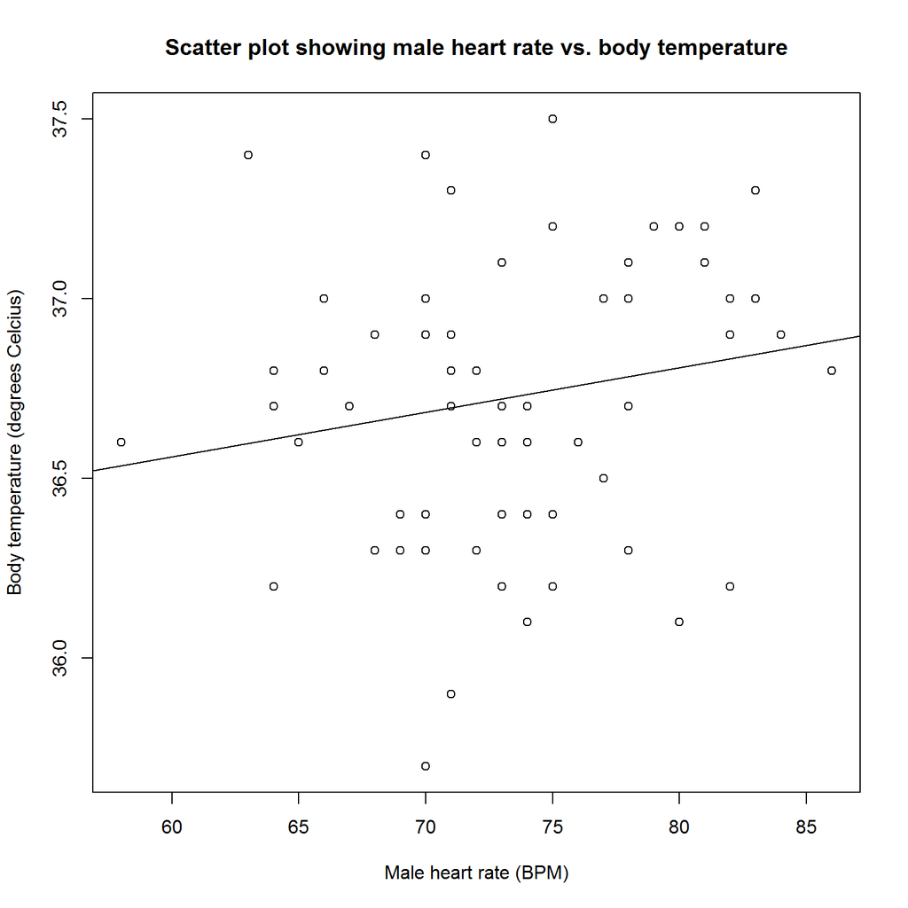

```r
#plot data (males)
male_plot <- plot(x = Q1_male$male, y = Q1_male$body_temperature,
                  main = 'Scatter plot showing male heart rate vs. body temperature',
                  xlab = 'Male heart rate (BPM)',
                  ylab = 'Body temperature (degrees Celcius)')

#linear regression for males
male_rgl <- lm(body_temperature~male, data = Q1_male)
abline(male_rgl)
```

```r
#print regression line for males
summary(male_rgl)
```

```
##
## Call:
## lm(formula = body_temperature ~ male, data = Q1_male)
##
## Residuals:
##      Min       1Q   Median       3Q      Max
## -0.98425 -0.28425  0.05305  0.24062  0.80280
##
## Coefficients:
##              Estimate Std. Error t value Pr(>|t|)
## (Intercept) 35.813752   0.601771  59.514   <2e-16 ***
## male         0.012436   0.008176   1.521    0.133
## ---
## Signif. codes:  0 '***' 0.001 '**' 0.01 '*' 0.05 '.' 0.1 ' ' 1
##
## Residual standard error: 0.3843 on 63 degrees of freedom
## Multiple R-squared:  0.03542,    Adjusted R-squared:  0.02011
## F-statistic: 2.313 on 1 and 63 DF,  p-value: 0.1333
```

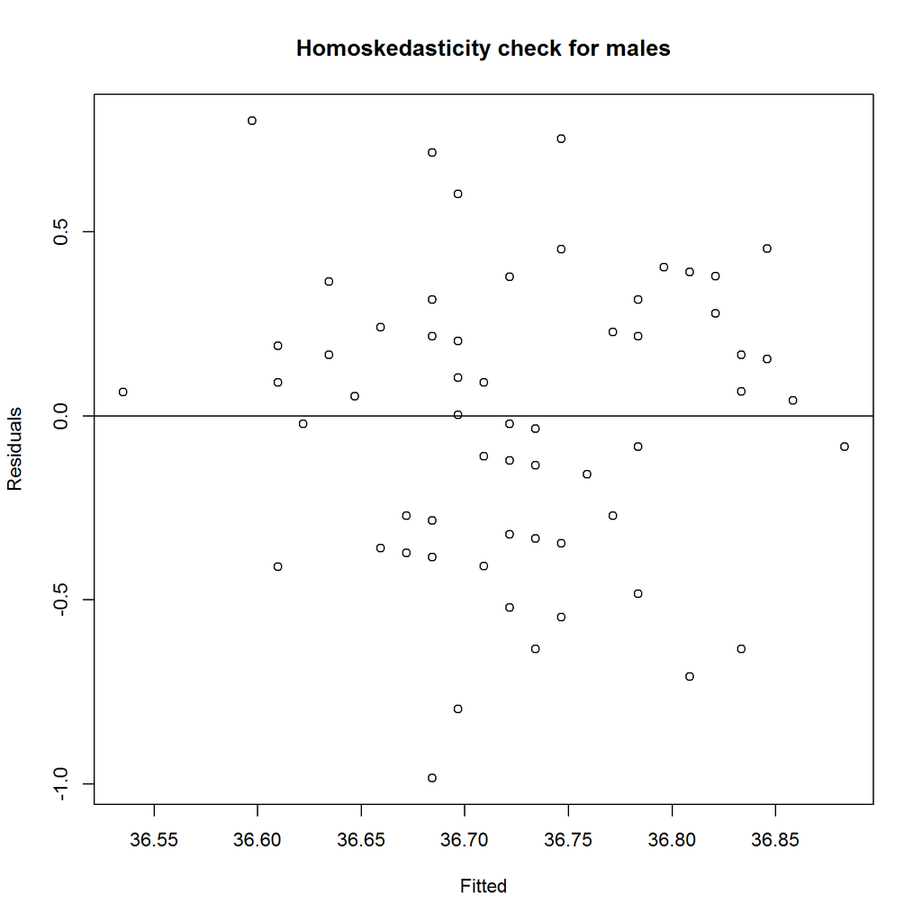

```r
#check homoskedasticity
male_homosk <- plot(x = male_rgl$fitted, y = male_rgl$residuals,
                    main = 'Homoskedasticity check for males',
                    xlab = 'Fitted', ylab = 'Residuals')
abline(h=0)
```

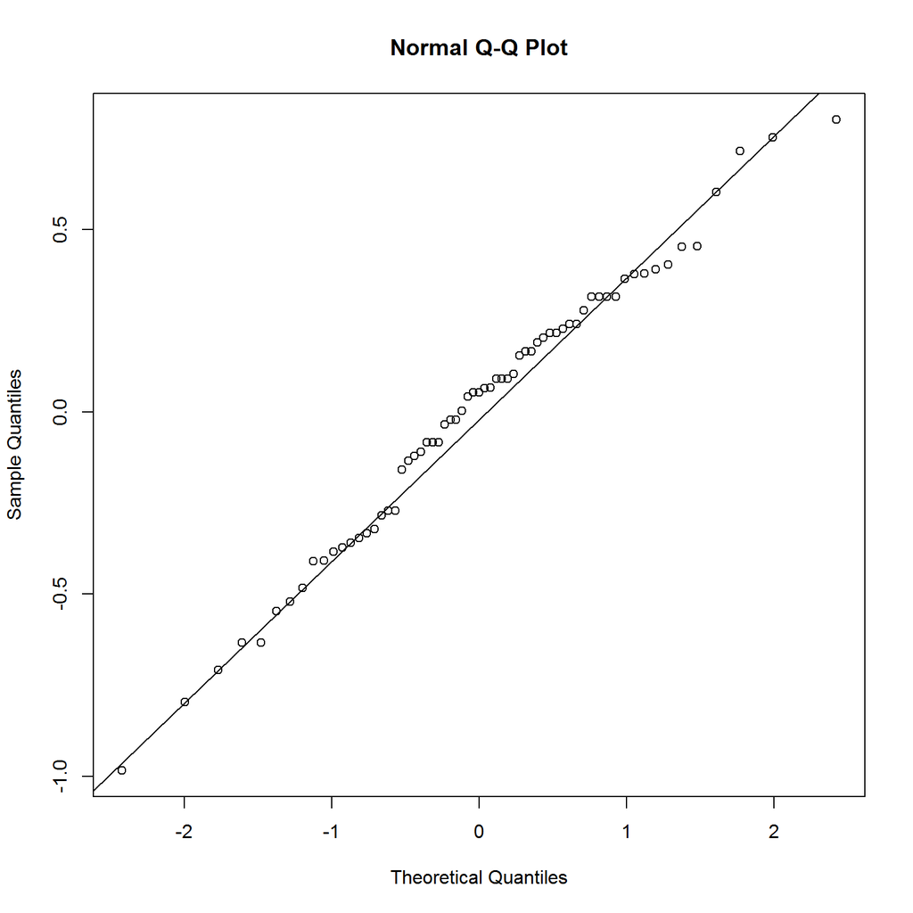

```r
#Check Gaussian distribution
qqnorm(male_rgl$residuals)
qqline(male_rgl$residuals)
```

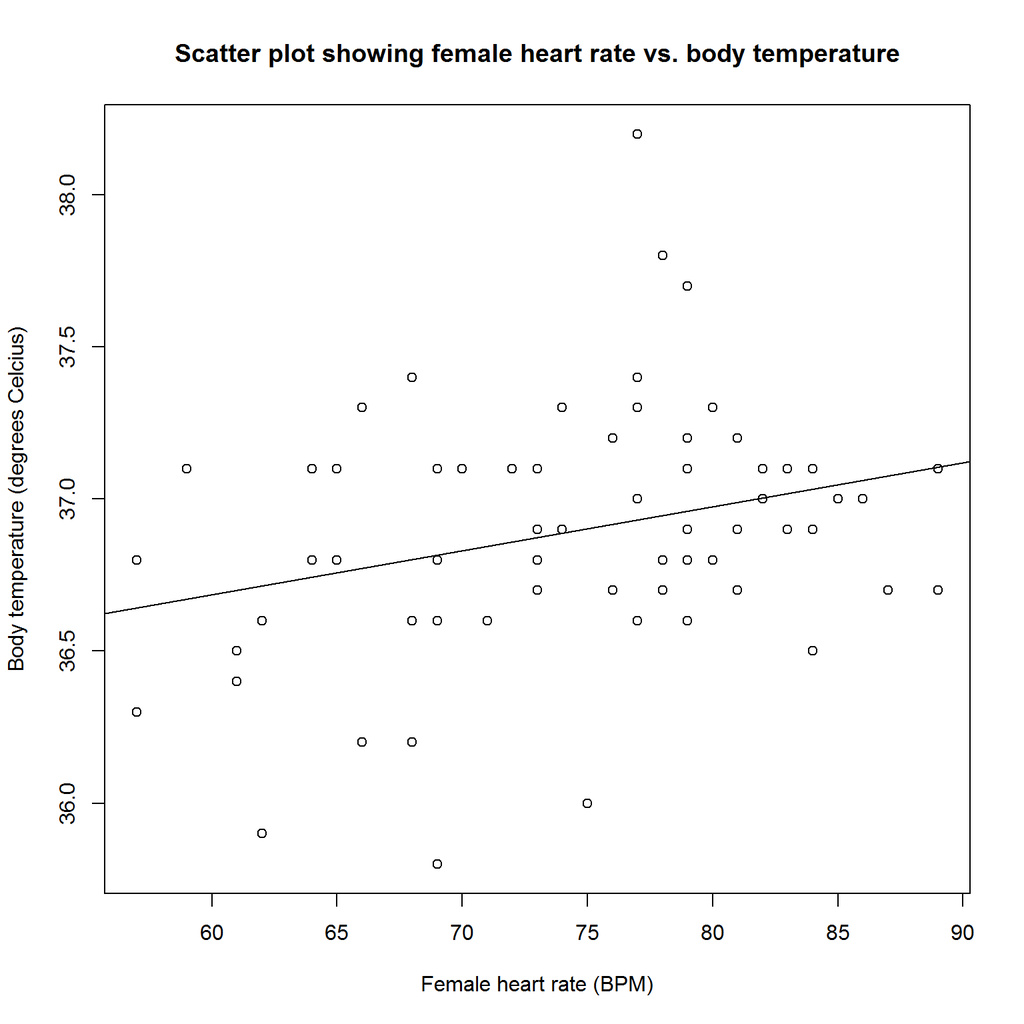

```r
#plot data (females)
female_plot <- plot(x = Q1_female$female, y = Q1_female$body_temperature,
                    main = 'Scatter plot showing female heart rate vs. body temperature',
                    xlab = 'Female heart rate (BPM)',
                    ylab = 'Body temperature (degrees Celcius)')

#linear regression for females
female_rgl <- lm(body_temperature~female, data = Q1_female)
abline(female_rgl)
```

```r
#print regression line for females
summary(female_rgl)
```

```
##
## Call:
## lm(formula = body_temperature ~ female, data = Q1_female)
##
## Residuals:
##      Min       1Q   Median       3Q      Max
## -1.01469 -0.21469 -0.01469  0.24192  1.26961
##
## Coefficients:
##              Estimate Std. Error t value Pr(>|t|)
## (Intercept) 35.816769   0.458825  78.062   <2e-16 ***
## female       0.014463   0.006151   2.351   0.0219 *
## ---
## Signif. codes:  0 '***' 0.001 '**' 0.01 '*' 0.05 '.' 0.1 ' ' 1
##
## Residual standard error: 0.3989 on 63 degrees of freedom
## Multiple R-squared:  0.08066,    Adjusted R-squared:  0.06607
## F-statistic: 5.528 on 1 and 63 DF,  p-value: 0.02186
```

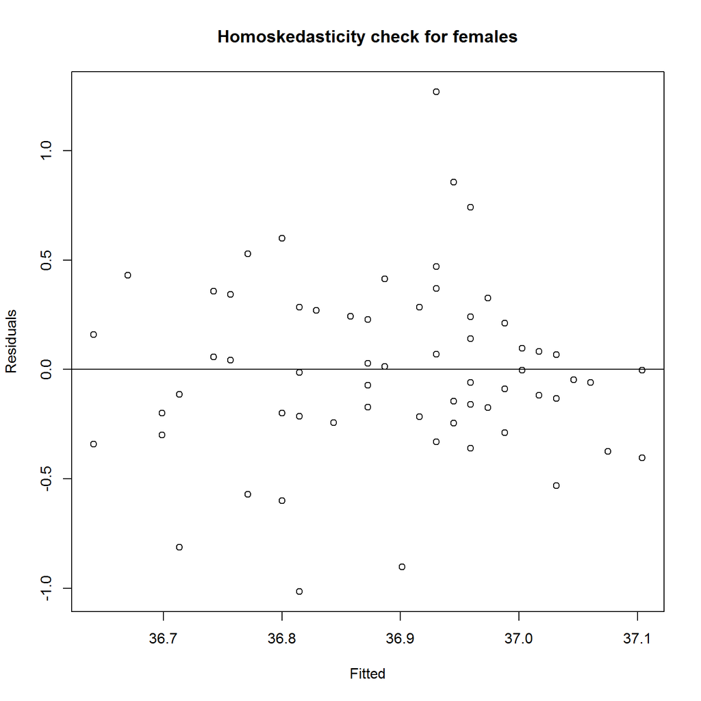

```r
#check homoskedasticity
female_homosk <- plot(x = female_rgl$fitted, y = female_rgl$residuals,
                    main = 'Homoskedasticity check for females',
                    xlab = 'Fitted', ylab = 'Residuals')
abline(h=0)
```

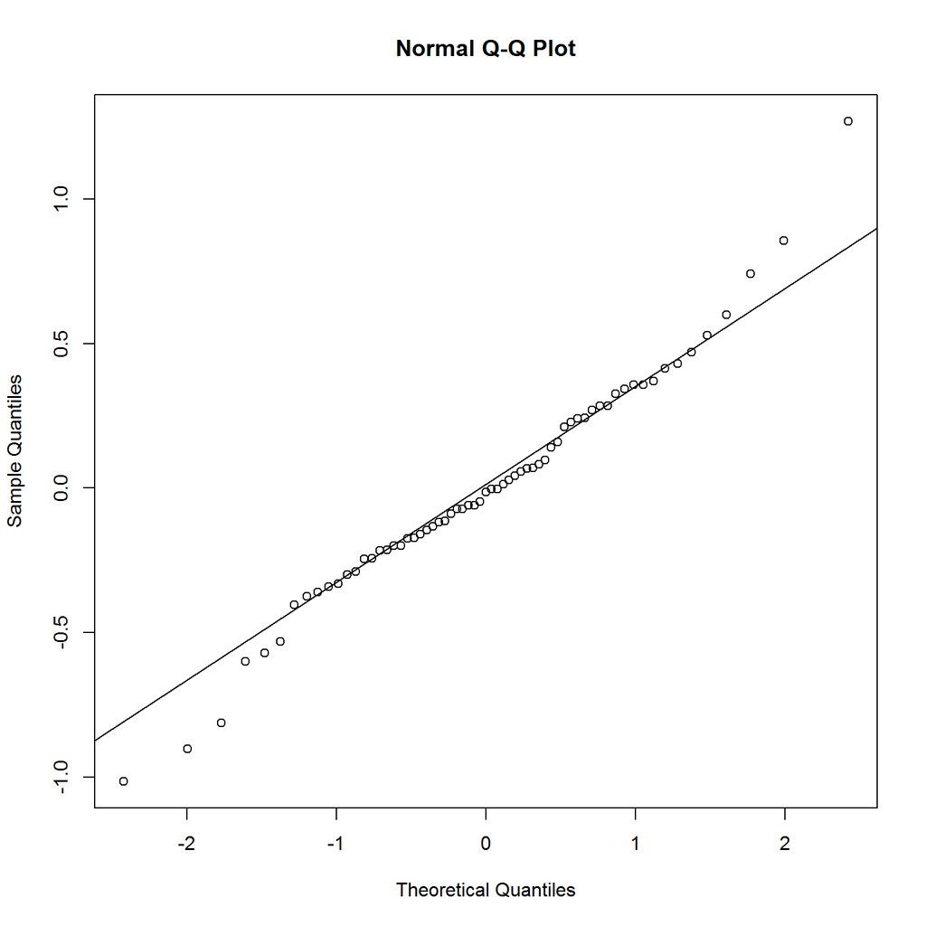

```r
#Check Gaussian distribution
qqnorm(female_rgl$residuals)
qqline(female_rgl$residuals)
```

**Null Hypothesis:** Heart rates in males and females have no association with body temperature.

**Alternative Hypothesis:** Heart rates in males and females have an association with body temperature.

**Assumptions:**

1. a = 0.05
2. Paired, continuous data set.
3. Parametric data set because normal distribution indicated by a normal Q-Q plot.
4. Residuals are normally distributed as shown by homoskedasticity check.
5. Reject null hypothesis if p < a.
6. Pearson’s correlation will be used to test hypothesis.

```r
#male Pearson's correlation
male_cor <- with(Q1_male,
                 cor.test(x = male, y = body_temperature,
                          method = 'pearson'))
male_cor
```

```
##
##  Pearson's product-moment correlation
##
## data:  male and body_temperature
## t = 1.521, df = 63, p-value = 0.1333
## alternative hypothesis: true correlation is not equal to 0
## 95 percent confidence interval:
##  -0.05837844  0.41313575
## sample estimates:
##       cor
## 0.1882004
```

```r
#male paired t-test
male_test <- t.test(Q1_male$male, Q1_male$body_temperature, paired = TRUE)
male_test
```

```
##
##  Paired t-test
##
## data:  Q1_male$male and Q1_male$body_temperature
## t = 50.807, df = 64, p-value < 2.2e-16
## alternative hypothesis: true difference in means is not equal to 0
## 95 percent confidence interval:
##  35.20228 38.08387
## sample estimates:
## mean of the differences
##                36.64308
```

```r
#female Pearson's correlation
female_cor <- with(Q1_female,
                 cor.test(x = female, y = body_temperature,
                          method = 'pearson'))
female_cor
```

```
##
##  Pearson's product-moment correlation
##
## data:  female and body_temperature
## t = 2.3511, df = 63, p-value = 0.02186
## alternative hypothesis: true correlation is not equal to 0
## 95 percent confidence interval:
##  0.04310142 0.49371392
## sample estimates:
##       cor
## 0.2840149
```

```r
#female paired t-test
female_test <- t.test(Q1_female$female, Q1_female$body_temperature, paired = TRUE)
female_test
```

```
##
##  Paired t-test
##
## data:  Q1_female$female and Q1_female$body_temperature
## t = 37.565, df = 64, p-value < 2.2e-16
## alternative hypothesis: true difference in means is not equal to 0
## 95 percent confidence interval:
##  35.28286 39.24637
## sample estimates:
## mean of the differences
##                37.26462
```

# Question 2 (*incomplete*)

## Handedness compared to ataxic walking and intoxication

```r
#load data set
df_Q2 <- read.csv('question2.csv')

#select data
Q2_data <- df_Q2 %>%
  select(handedness, final_position)

Q2_data2 <- df_Q2 %>%
  select(handedness, first_stumble)

#display data
head(Q2_data, 6)
```

```
##   handedness final_position
## 1          1              1
## 2          1              1
## 3          1              1
## 4          1              0
## 5          1              0
## 6          0              1
```

```r
head(Q2_data2)
```

```
##   handedness first_stumble
## 1          1             1
## 2          1             1
## 3          1             1
## 4          1             1
## 5          1             0
## 6          0             0
```

```r
#Counts (handedness and first stumble)
#Right hand with right side
rightS_side <- Q2_data2 %>%
  filter(handedness == 1) %>%
filter(first_stumble == 1)

rightS_count <- count(rightS_side)
rightS_count
```

```
## # A tibble: 1 x 1
##       n
##   <int>
## 1    53
```

```r
#Left hand with left side
leftS_side <- Q2_data2 %>%
  filter(handedness == 0) %>%
  filter(first_stumble == 0)

leftS_count <- count(leftS_side)
leftS_count
```

```
## # A tibble: 1 x 1
##       n
##   <int>
## 1    54
```

```r
#Right hand with left side
rightS_left <- Q2_data2 %>%
  filter(handedness == 1) %>%
  filter(first_stumble == 0)

rightS_left_count <- count(rightS_left)
rightS_left_count
```

```
## # A tibble: 1 x 1
##       n
##   <int>
## 1    22
```

```r
#Left hand with right side
leftS_right <- Q2_data2 %>%
  filter(handedness == 0) %>%
  filter(first_stumble == 1)

left_rightS_count <- count(leftS_right)
left_rightS_count
```

```
## # A tibble: 1 x 1
##       n
##   <int>
## 1    22
```

```r
#Counts (handedness and position and end of walk)
#Right hand with right side
right_side <- Q2_data %>%
  filter(handedness == 1) %>%
filter(final_position == 1)

right_count <- count(right_side)
right_count
```

```
## # A tibble: 1 x 1
##       n
##   <int>
## 1    48
```

```r
#Left hand with left side
left_side <- Q2_data %>%
  filter(handedness == 0) %>%
  filter(final_position == 0)

left_count <- count(left_side)
left_count
```

```
## # A tibble: 1 x 1
##       n
##   <int>
## 1    40
```

```r
#Right hand with left side
right_left <- Q2_data %>%
  filter(handedness == 1) %>%
  filter(final_position == 0)

right_left_count <- count(right_left)
right_left_count
```

```
## # A tibble: 1 x 1
##       n
##   <int>
## 1    27
```

```r
#Left hand with right side
left_right <- Q2_data %>%
  filter(handedness == 0) %>%
  filter(final_position == 1)

left_right_count <- count(left_right)
left_right_count
```

```
## # A tibble: 1 x 1
##       n
##   <int>
## 1    36
```

```r
#Form table
Q2_dataFrame <- data.frame(Handedness = c('Right', 'Left'),
                           Direction_first_stumble = c(53,22,22,54),
                           Position_at_end = c(48,27,36,40))
Q2_dataFrame
```

```
##   Handedness Direction_first_stumble Position_at_end
## 1      Right                      53              48
## 2       Left                      22              27
## 3      Right                      22              36
## 4       Left                      54              40
```

[figure not shown]

```r
#plot data
direction_plot <- xtabs(~Handedness + Direction_first_stumble, data = Q2_dataFrame)
mosaicplot(direction_plot,
           main = 'Mosaic plot representing direction of first stumble between right and left handed individuals',
           xlab = 'Handedness', ylab = 'Number of people')
```

[figure not shown]

```r
position_plot <- xtabs(~Handedness + Position_at_end, data = Q2_dataFrame)
mosaicplot(position_plot,
           main = 'Mosaic plot representing position at the end of line between right and left handed individuals',
           xlab = 'Handedness', ylab = 'Number of people')
```

**Null Hypothesis:** Handedness is not associated with ataxic walking in intoxicated individuals.

**Alternative Hypothesis:** Handedness is associated with ataxic walking in intoxicated individuals.

**Assumptions:**

1. a = 0.05
2. Paired data set
3. Parametric data set
4. Reject null hypothesis if p < a
5. Fisher’s exact test with a Holm adustment method will be required to test hypothesis.

```r
#Test counts of first stumble and position and the end line with handedness of individuals.

#handedness and stumble test


#handedness and position at the end test
```

# Question 3

## Can running time be used to predict calories burned?

[figure not shown]

```r
#load data set
df_Q3 <- read_csv('question3.csv')

#plot data set
Q3_plot <- plot(time~calories, data = df_Q3,
                main = 'Scatter plot representing running time vs. calories burnt' ,
                xlab = 'Running Time (s)', ylab = 'Calories consumed(cal)')

#tidy data
Q3_run <- select(df_Q3, time, calories)

#linear regression
run_rgl <- lm(calories~time, data = Q3_run)
abline(run_rgl)
```

```r
#print regression line for males
summary(run_rgl)
```

```
##
## Call:
## lm(formula = calories ~ time, data = Q3_run)
##
## Residuals:
##    Min     1Q Median     3Q    Max
## -60.76 -15.09   4.04  15.67  55.21
##
## Coefficients:
##              Estimate Std. Error t value Pr(>|t|)
## (Intercept) 939.36422  150.70365   6.233 9.09e-06 ***
## time         -0.28031    0.07432  -3.772  0.00152 **
## ---
## Signif. codes:  0 '***' 0.001 '**' 0.01 '*' 0.05 '.' 0.1 ' ' 1
##
## Residual standard error: 30.17 on 17 degrees of freedom
## Multiple R-squared:  0.4556, Adjusted R-squared:  0.4235
## F-statistic: 14.22 on 1 and 17 DF,  p-value: 0.001522
```

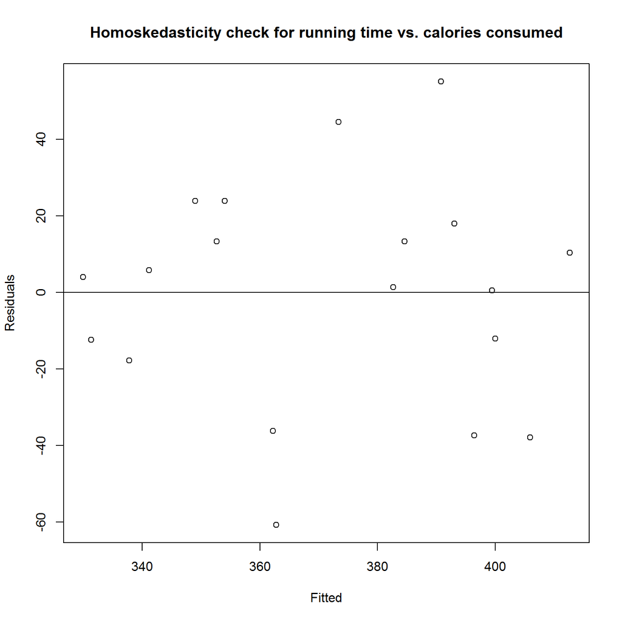

```r
#check homoskedasticity
run_homosk <- plot(x = run_rgl$fitted, y = run_rgl$residuals,
                    main = 'Homoskedasticity check for running time vs. calories consumed',
                    xlab = 'Fitted', ylab = 'Residuals')
abline(h=0)
```

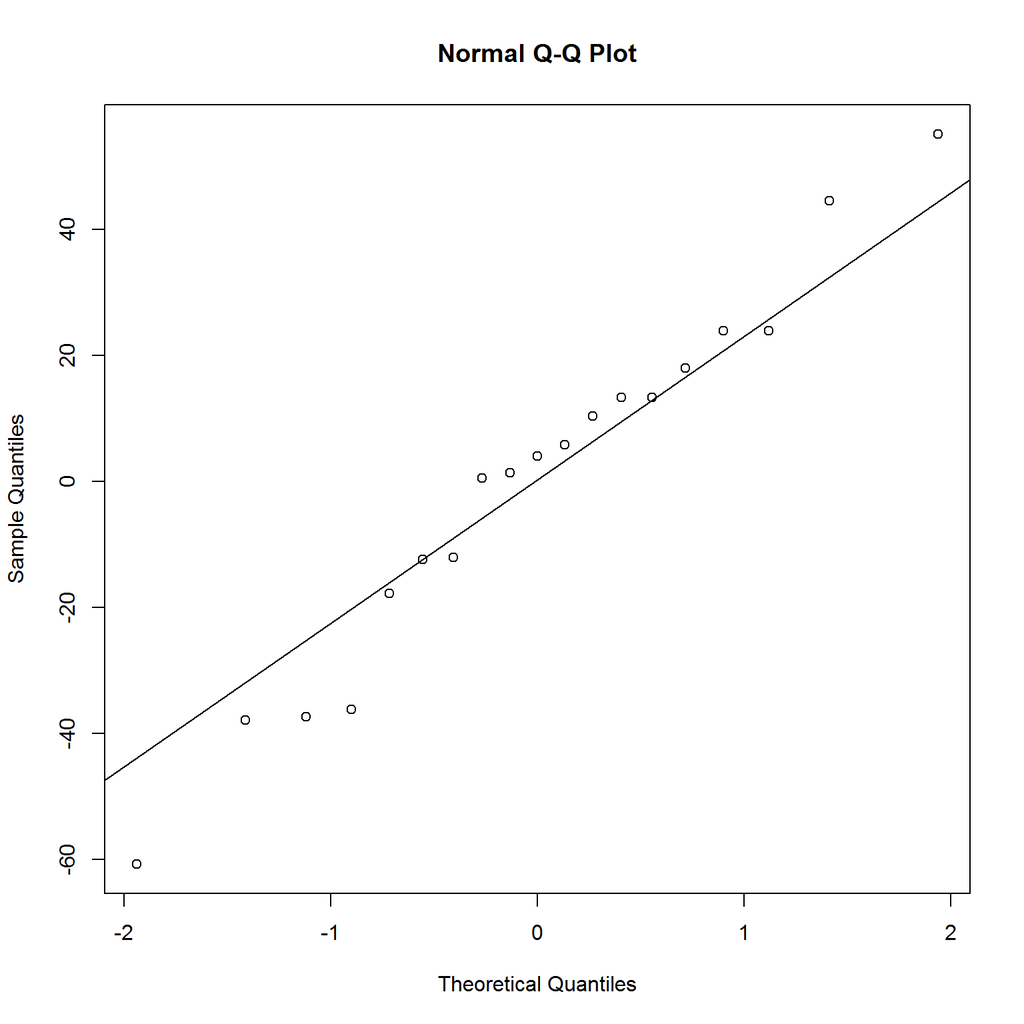

```r
#Check Gaussian distribution
qqnorm(run_rgl$residuals)
qqline(run_rgl$residuals)
```

**Null Hypothesis:** Running time (s) cannot be used to predict number of calories consumed (cal) during a run.

**Alternative Hypothesis:** Running time (s) can be used to predict number of calories consumed (cal) during a run.

```r
#Pearson's correlation
run_cor <- with(Q3_run,
                 cor.test(x = time, y = calories,
                          method = 'pearson'))
run_cor
```

```
##
##  Pearson's product-moment correlation
##
## data:  time and calories
## t = -3.7715, df = 17, p-value = 0.001522
## alternative hypothesis: true correlation is not equal to 0
## 95 percent confidence interval:
##  -0.8642170 -0.3183295
## sample estimates:
##        cor
## -0.6749491
```

```r
#calculate regression coefficient
regco <- coefficients(run_rgl)
regco
```

```
## (Intercept)        time
## 939.3642218  -0.2803149
```

```r
#fit coeffiecients into regression formula
origTime <- 30
decTimeSec <- origTime * 60
run_time <- mean(df_Q3$run) - decTimeSec
CaloriesC <- regco[1] + regco[2] * run_time
CaloriesC
```

```
## (Intercept)
##    1441.128
```

**Results:**

p < a, thus reject null hypothesis.

**Conclusion:** Running time has a strong, negative correlation with calories burnt. Therefore the shorter runs burn more calories than longer runs.

# Questions 4

## The relationship between project mark and final mark for BSc Honours Physiology students over 10 years.

```r
foo <- rnorm(10000, mean = 60, sd = 3) # final mark
bar <- rnorm(10000, mean = 68, sd = 5) # project mark
baz <- rep(seq(from = 1997, to = 2006), each = 1) # years

year <- sample(baz, 150, replace = TRUE,
               prob = c(0.05, 0.05, 0.08, 0.08,
                          0.1, 0.13, 0.14, 0.13, 0.12, 0.12))
project_mark <- sample(bar, 150, replace = TRUE)
final_mark <- sample(foo, 150, replace = TRUE)

plot_data <- data_frame(year = year,
                        project_mark = round(project_mark, 1),
                        final_mark = round(final_mark, 1)) %>%
    arrange(year)
#Print out data
head(plot_data, 6)
```

```
## # A tibble: 6 x 3
##    year project_mark final_mark
##   <int>        <dbl>      <dbl>
## 1  1997         65.1       61.2
## 2  1997         70.7       62.3
## 3  1997         69.8       58.4
## 4  1997         63.6       58.1
## 5  1997         68.3       62.6
## 6  1997         67.2       57.5
```

```r
#Scatter plot of data
mark_plot <- plot(x = project_mark, y = final_mark,
     main = 'Scatter plot representing project mark vs. final mark of BSc Honours Physiology students',
     xlab = 'Project mark (%)', ylab = 'Final year mark (%)')

#regression line
mark_regl <- lm(final_mark~project_mark)
abline(mark_regl)
```

[figure not shown]

```r
#print summary of regression
summary(mark_regl)
```

```
##
## Call:
## lm(formula = final_mark ~ project_mark)
##
## Residuals:
##     Min      1Q  Median      3Q     Max
## -7.9725 -1.9759  0.0476  2.4768  6.5390
##
## Coefficients:
##              Estimate Std. Error t value Pr(>|t|)
## (Intercept)  54.71675    3.07843  17.774   <2e-16 ***
## project_mark  0.07112    0.04536   1.568    0.119
## ---
## Signif. codes:  0 '***' 0.001 '**' 0.01 '*' 0.05 '.' 0.1 ' ' 1
##
## Residual standard error: 2.952 on 148 degrees of freedom
## Multiple R-squared:  0.01634,    Adjusted R-squared:  0.009692
## F-statistic: 2.458 on 1 and 148 DF,  p-value: 0.119
```

**Explanation of axis:**

**x-axis =** project mark (independent variable) because is not affected by final year mark, however affects final year mark.

**y-axis =** final year marl (dependent variable) because is affected by individual project marks over the years.